# The most harmful weather events with respect to population health and economic consequences

## Loading required libraries

## Loading and processing raw data

The data is obtained from [NOAA database] (https://www.ncdc.noaa.gov/stormevents/). This file contains the data between 1950 - 2011.

```r
URL <- "https://d396qusza40orc.cloudfront.net/repdata%2Fdata%2FStormData.csv.bz2"

destfolder <- "./stormdata"
        if (!dir.exists(destfolder)) {dir.create (destfolder)}

destfile <- "./stormdata/stormdata.csv"
        if (!file.exists(destfile)) {download.file(URL, destfile ="./stormdata/stormdata.csv")}
raw.data <- read.csv ("./stormdata/stormdata.csv")
```

After loading the data file, we would have a quick scan through the data file to get familiarized with the information.

Looking at the data structure:

```r
str(raw.data)
```

```
## 'data.frame':    902297 obs. of  37 variables:
##  $ STATE__   : num  1 1 1 1 1 1 1 1 1 1 ...
##  $ BGN_DATE  : Factor w/ 16335 levels "1/1/1966 0:00:00",..: 6523 6523 4242 11116 2224 2224 2260 383 3980 3980 ...
##  $ BGN_TIME  : Factor w/ 3608 levels "00:00:00 AM",..: 272 287 2705 1683 2584 3186 242 1683 3186 3186 ...
##  $ TIME_ZONE : Factor w/ 22 levels "ADT","AKS","AST",..: 7 7 7 7 7 7 7 7 7 7 ...
##  $ COUNTY    : num  97 3 57 89 43 77 9 123 125 57 ...
##  $ COUNTYNAME: Factor w/ 29601 levels "","5NM E OF MACKINAC BRIDGE TO PRESQUE ISLE LT MI",..: 13513 1873 4598 10592 4372 10094 1973 23873 24418 4598 ...
##  $ STATE     : Factor w/ 72 levels "AK","AL","AM",..: 2 2 2 2 2 2 2 2 2 2 ...
##  $ EVTYPE    : Factor w/ 985 levels "   HIGH SURF ADVISORY",..: 834 834 834 834 834 834 834 834 834 834 ...
##  $ BGN_RANGE : num  0 0 0 0 0 0 0 0 0 0 ...
##  $ BGN_AZI   : Factor w/ 35 levels "","  N"," NW",..: 1 1 1 1 1 1 1 1 1 1 ...
##  $ BGN_LOCATI: Factor w/ 54429 levels "","- 1 N Albion",..: 1 1 1 1 1 1 1 1 1 1 ...
##  $ END_DATE  : Factor w/ 6663 levels "","1/1/1993 0:00:00",..: 1 1 1 1 1 1 1 1 1 1 ...
##  $ END_TIME  : Factor w/ 3647 levels ""," 0900CST",..: 1 1 1 1 1 1 1 1 1 1 ...
##  $ COUNTY_END: num  0 0 0 0 0 0 0 0 0 0 ...
```

[output cut: 23 more lines]

Looking at the first 6 rows of the data

```r
head (raw.data)
```

```
##   STATE__           BGN_DATE BGN_TIME TIME_ZONE COUNTY COUNTYNAME STATE
## 1       1  4/18/1950 0:00:00     0130       CST     97     MOBILE    AL
## 2       1  4/18/1950 0:00:00     0145       CST      3    BALDWIN    AL
## 3       1  2/20/1951 0:00:00     1600       CST     57    FAYETTE    AL
## 4       1   6/8/1951 0:00:00     0900       CST     89    MADISON    AL
## 5       1 11/15/1951 0:00:00     1500       CST     43    CULLMAN    AL
## 6       1 11/15/1951 0:00:00     2000       CST     77 LAUDERDALE    AL
##    EVTYPE BGN_RANGE BGN_AZI BGN_LOCATI END_DATE END_TIME COUNTY_END
## 1 TORNADO         0                                               0
## 2 TORNADO         0                                               0
## 3 TORNADO         0                                               0
## 4 TORNADO         0                                               0
## 5 TORNADO         0                                               0
## 6 TORNADO         0                                               0
##   COUNTYENDN END_RANGE END_AZI END_LOCATI LENGTH WIDTH F MAG FATALITIES
```

[output cut: 20 more lines]

To prepare the data for our analysis and in order to calculate the economic damage of the weather events, we will be looking at two variables: Property damage (PropDMG) and crop damage (CropDMG). PropDMG and CropDMG are numeric variables which are associated with PropDMGEXP and CropDMGEXP factor variables indicating thousand, million, billion, etc. We will combine the numeric and factor variables for Property and Crop damages together to get one number representing the correct dollar value.

Finding the levels in PropDMGEXP variable:

```r
unique(raw.data$PROPDMGEXP)
```

```
##  [1] K M   B m + 0 5 6 ? 4 2 3 h 7 H - 1 8
## Levels:  - ? + 0 1 2 3 4 5 6 7 8 B h H K m M
```

Finding the levels in CropDMGEXP variable:

```r
unique(raw.data$CROPDMGEXP)
```

```
## [1]   M K m B ? 0 k 2
## Levels:  ? 0 2 B k K m M
```

Assigning values to each level:

```r
raw.data$PROPEXP[raw.data$PROPDMGEXP == "K"]  <- 1000
raw.data$PROPEXP[raw.data$PROPDMGEXP == "M"]   <-  1000000
raw.data$PROPEXP[raw.data$PROPDMGEXP == ""]   <-  1
raw.data$PROPEXP[raw.data$PROPDMGEXP == "B"]   <-  1000000000
raw.data$PROPEXP[raw.data$PROPDMGEXP == "m"]   <-  1000000
raw.data$PROPEXP[raw.data$PROPDMGEXP == "+"]   <-  0
raw.data$PROPEXP[raw.data$PROPDMGEXP == "0"]   <-  1
raw.data$PROPEXP[raw.data$PROPDMGEXP == "5"]   <-  100000
raw.data$PROPEXP[raw.data$PROPDMGEXP == "6"]   <-  1000000
raw.data$PROPEXP[raw.data$PROPDMGEXP == "?"]   <-  0
raw.data$PROPEXP[raw.data$PROPDMGEXP == "4"]   <-  10000
raw.data$PROPEXP[raw.data$PROPDMGEXP == "2"]   <-  100
raw.data$PROPEXP[raw.data$PROPDMGEXP == "3"]   <-  1000
raw.data$PROPEXP[raw.data$PROPDMGEXP == "h"]   <-  100
raw.data$PROPEXP[raw.data$PROPDMGEXP == "7"]   <-  10000000
raw.data$PROPEXP[raw.data$PROPDMGEXP == "H"]   <-  100
raw.data$PROPEXP[raw.data$PROPDMGEXP == "-"]   <-  0
raw.data$PROPEXP[raw.data$PROPDMGEXP == "1"]   <-  10
raw.data$PROPEXP[raw.data$PROPDMGEXP == "8"]   <-  100000000


raw.data$CROPEXP[raw.data$CROPDMGEXP == ""]   <-  1
raw.data$CROPEXP[raw.data$CROPDMGEXP == "M"]   <-  1000000
raw.data$CROPEXP[raw.data$CROPDMGEXP == "K"]   <-  1000
raw.data$CROPEXP[raw.data$CROPDMGEXP == "m"]   <-  1000000000
raw.data$CROPEXP[raw.data$CROPDMGEXP == "B"]   <-  1000000
raw.data$CROPEXP[raw.data$CROPDMGEXP == "?"]   <-  0
raw.data$CROPEXP[raw.data$CROPDMGEXP == "0"]   <-  1
raw.data$CROPEXP[raw.data$CROPDMGEXP == "k"]   <-  1000
raw.data$CROPEXP[raw.data$CROPDMGEXP == "2"]   <-  100


raw.data$PROPDMGVAL <- raw.data$PROPDMG * raw.data$PROPEXP
raw.data$CROPDMGVAL <- raw.data$CROPDMG * raw.data$CROPEXP
```

And finally adding property damage values and Crop damage values to calculate total economic damage:

```r
raw.data$ALLDMGVAL <- raw.data$PROPDMGVAL + raw.data$CROPDMGVAL
```

Now the data is ready for analysis. In order to investigate the effect of each event, the data will be grouped by event type. Total numbers of fatalities, injuries and economical damage will be calculated and stored in separate objects as below:

```r
EveType_grouped <- raw.data %>% group_by (EVTYPE) %>% summarise (sum_fatality = sum (FATALITIES, na.rm=TRUE), sum_injuries = sum (INJURIES, na.rm= TRUE), sum_economic_DMG = sum (ALLDMGVAL, na.rm = TRUE))

head (EveType_grouped)
```

```
## # A tibble: 6 x 4
##   EVTYPE                  sum_fatality sum_injuries sum_economic_DMG
##   <fct>                          <dbl>        <dbl>            <dbl>
## 1 "   HIGH SURF ADVISORY"            0            0           200000
## 2 " COASTAL FLOOD"                   0            0                0
## 3 " FLASH FLOOD"                     0            0            50000
## 4 " LIGHTNING"                       0            0                0
## 5 " TSTM WIND"                       0            0          8100000
## 6 " TSTM WIND (G45)"                 0            0             8000
```

```r
Fatalities <- EveType_grouped %>% select (EVTYPE, sum_fatality) %>% arrange(-sum_fatality)
```

```r
Injuries <- EveType_grouped %>% select (EVTYPE, sum_injuries) %>% arrange(-sum_injuries)
```

```r
Economic_DMG <- EveType_grouped %>% select (EVTYPE, sum_economic_DMG) %>% arrange(-sum_economic_DMG)
```

# Results

To find the highest damaging events, the top 10 events in terms of the damage caused by them are pulled out. The results are shown in the tables as well as in the graphs:

Top 10 fatal events followed:

```r
Top_fatal <- Fatalities %>% top_n (10)
Top_fatal
```

```
## # A tibble: 10 x 2
##    EVTYPE         sum_fatality
##    <fct>                 <dbl>
##  1 TORNADO                5633
##  2 EXCESSIVE HEAT         1903
##  3 FLASH FLOOD             978
##  4 HEAT                    937
##  5 LIGHTNING               816
##  6 TSTM WIND               504
##  7 FLOOD                   470
##  8 RIP CURRENT             368
##  9 HIGH WIND               248
## 10 AVALANCHE               224
```

Top 10 injury caused events:

```r
Top_injured <- Injuries %>% top_n (10)
Top_injured
```

```
## # A tibble: 10 x 2
##    EVTYPE            sum_injuries
##    <fct>                    <dbl>
##  1 TORNADO                  91346
##  2 TSTM WIND                 6957
##  3 FLOOD                     6789
##  4 EXCESSIVE HEAT            6525
##  5 LIGHTNING                 5230
##  6 HEAT                      2100
##  7 ICE STORM                 1975
##  8 FLASH FLOOD               1777
##  9 THUNDERSTORM WIND         1488
## 10 HAIL                      1361
```

Graphing the top 10 events in terms of fatalities and injruies caused by them:

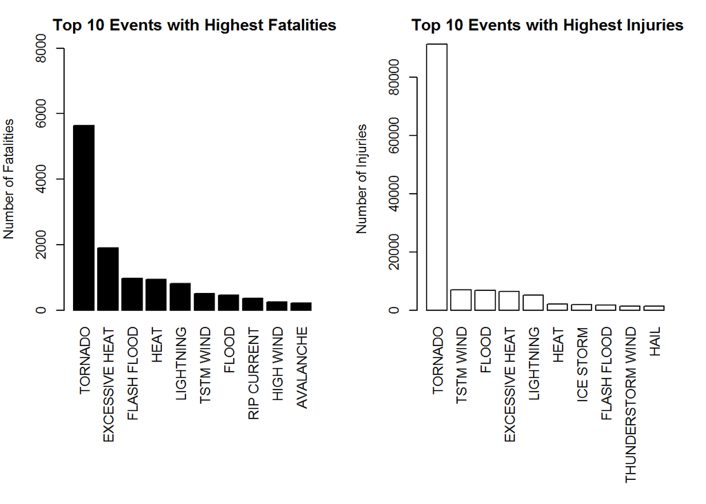

```r
par(mfrow = c(1, 2), mar = c(12, 4, 3, 2), mgp = c(3, 1, 0), las=3, cex = 0.8)
barplot(Top_fatal$sum_fatality, names.arg=Top_fatal$EVTYPE, ylim= c(0,8000),col="Black",ylab="Number of Fatalities", main=" Top 10 Events with Highest Fatalities")

barplot(Top_injured$sum_injuries, names.arg=Top_injured$EVTYPE,ylim= c(0,90000), col="White", ylab="Number of Injuries", main=" Top 10 Events with Highest Injuries")
```

Top 10 economical damaging events::

```r
Top_Economic_DMG <- Economic_DMG %>% top_n (10)
Top_Economic_DMG
```

```
## # A tibble: 10 x 2
##    EVTYPE            sum_economic_DMG
##    <fct>                        <dbl>
##  1 FLOOD                150319678257
##  2 HURRICANE/TYPHOON     70405222800
##  3 TORNADO               57362333886.
##  4 STORM SURGE           43323541000
##  5 HAIL                  18761221986.
##  6 FLASH FLOOD           18243991078.
##  7 HURRICANE             14610229010
##  8 DROUGHT               13520172000
##  9 HURRICANE OPAL        13181846000
## 10 TROPICAL STORM         8382236550
```

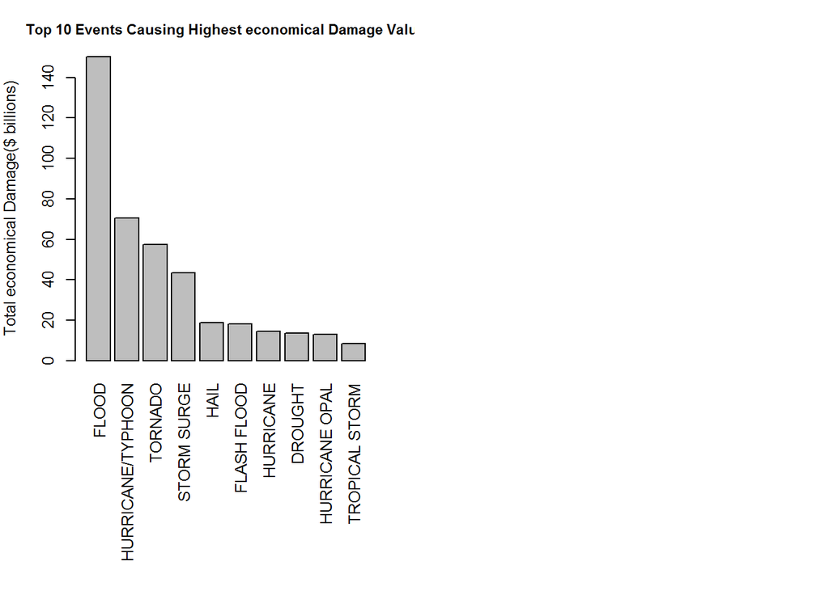

```r
par(mfrow = c(1, 2), mar = c(12, 4, 3, 2), mgp = c(3, 1, 0), las=3, cex = 0.8, cex.main = 0.9)

barplot((Top_Economic_DMG$sum_economic_DMG)/(1*1000000000), names.arg=Top_Economic_DMG$EVTYPE, col="Gray", ylab=" Total economical Damage($ billions)", main="Top 10 Events Causing Highest economical Damage Value")
```

Conclusion:

Based on the results, Tornado is the highest riskful event for public health in terms of death, followed by excessive heat. However, in terms of injury, Tornado and TSTM wind are among the most injury-causing events. When it comes to economic damage which is defined as damage to properties as well as crops, the flood is the most severe event followed by Hurricane.